# hw4

Author

Andre Gala-Garza

Published

April 12, 2026

**Disclaimer:** Generative AI was used to assist with templating and writing code in this assignment; however, this code was checked manually and edited by hand to ensure accuracy.

**Source:** OpenAI. (2026). *ChatGPT* [Large language model]. https://chatgpt.com/.

```r
knitr::opts_chunk$set(echo = TRUE)

options(
  max.print = 100,
  tibble.print_max = 10,
  tibble.width = Inf
)
```

```r
library(tidyverse)
library(dplyr)
```

# HPC

## Question 1: fun2

```r
# running cumulative sum by row
fun2 <- function(mat) {
  n <- nrow(mat)
  k <- ncol(mat)
  ans <- mat
  for (i in 1:n) {
    for (j in 2:k) {
      ans[i,j] <- mat[i, j] + ans[i, j - 1]
    }
  }
  ans
}

fun2alt <- function(mat) {
  k <- ncol(mat)
  ans <- mat
  for (j in 2:k) {
    ans[, j] <- ans[, j] + ans[, j - 1]
  }
  ans
}
```

```r
# Use the functions with this data
set.seed(2315)
dat <- matrix(rnorm(200 * 100), nrow = 200)
```

```r
# Check that both functions give the same result
out1 <- fun2(dat)
out2 <- fun2alt(dat)

all.equal(out1, out2)
```

```
[1] TRUE
```

```r
# Benchmark test
library(microbenchmark)

mb <- microbenchmark(
  original = fun2(dat),
  faster = fun2alt(dat),
  times = 100
)

mb
```

```
Unit: microseconds
     expr  min      lq     mean median      uq     max neval
 original 1881 1976.65 2320.183 2101.7 2374.50  5999.2   100
   faster  272  466.40  641.357  496.1  559.75 11603.5   100
```

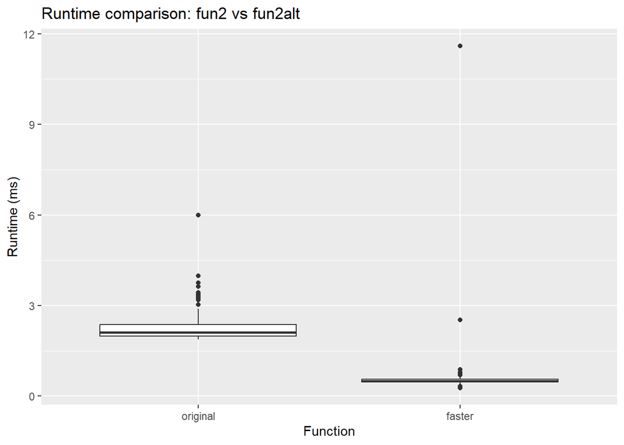

```r
library(ggplot2)

mb_df <- as.data.frame(mb)

ggplot(mb_df, aes(x = expr, y = time / 1e6)) +
  geom_boxplot() +
  labs(
    title = "Runtime comparison: fun2 vs fun2alt",
    x = "Function",
    y = "Runtime (ms)"
  )
```

fun2alt() is faster because it keeps only one loop and performs each cumulative update on a whole column instead of one matrix element at a time, while still returning exactly the same output as fun2().

## Question 2: fun3

```r
fun3 <- function(x) {
  out <- numeric(length(x))
  cumsum_x <- 0
  for (i in seq_along(x)) {
    if (x[i] == 0) {
      cumsum_x <- 0
    } else {
      cumsum_x <- cumsum_x + x[i]
    }
    out[i] <- cumsum_x
  }
  out
}

fun3alt <- function(x) {
  cs <- cumsum(x)
  last_zero <- cummax(seq_along(x) * (x == 0))
  offset <- numeric(length(x))
  nz <- last_zero > 0
  offset[nz] <- cs[last_zero[nz]]
  cs - offset
}
```

```r
# Small example for easy checking
x_small <- c(3, 2, 1, 0, 5, 4, 0, 2, 2, 1, 0, 7)

# Larger random example
set.seed(2315)
x_big <- sample(c(0, -2:-1, 1:5), size = 100000, replace = TRUE)
```

```r
# Check accuracy
fun3(x_small)
```

```
 [1] 3 5 6 0 5 9 0 2 4 5 0 7
```

```r
fun3alt(x_small)
```

```
 [1] 3 5 6 0 5 9 0 2 4 5 0 7
```

```r
all.equal(fun3(x_small), fun3alt(x_small))
```

```
[1] TRUE
```

```r
all.equal(fun3(x_big), fun3alt(x_big))
```

```
[1] TRUE
```

```r
# Benchmark test
library(microbenchmark)

mb <- microbenchmark(
  original = fun3(x_big),
  faster = fun3alt(x_big),
  times = 100
)

mb
```

```
Unit: milliseconds
     expr    min      lq     mean  median      uq     max neval
 original 7.1555 8.01350 8.955787 8.65205 9.43465 14.6680   100
   faster 2.1105 3.31445 4.846403 4.16360 5.47345 11.8014   100
```

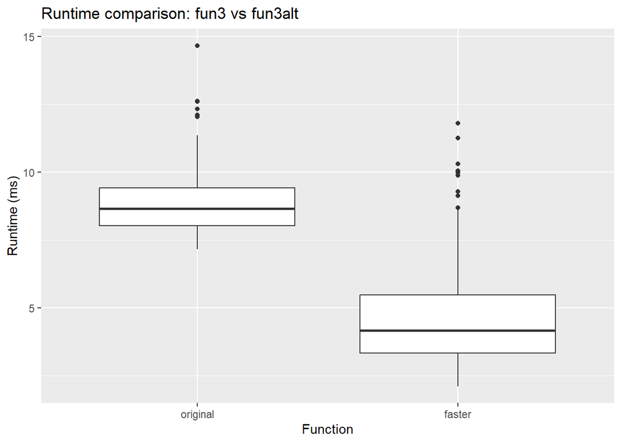

```r
library(ggplot2)

mb_df <- as.data.frame(mb)

ggplot(mb_df, aes(x = expr, y = time / 1e6)) +
  geom_boxplot() +
  labs(
    title = "Runtime comparison: fun3 vs fun3alt",
    x = "Function",
    y = "Runtime (ms)"
  )
```

fun3alt() is faster because it replaces the element-by-element R loop with vectorized base R operations (cumsum() and cummax()), which do the work in optimized internal code with less interpreter overhead.

## Question 3: sim_pi

```r
library(parallel)

sim_pi <- function(n = 1000, i = NULL) {
  p <- matrix(runif(n*2), ncol = 2)
  mean(rowSums(p^2) < 1) * 4
}

# Here is an example of the run
set.seed(156)
sim_pi(1000) # 3.132
```

```
[1] 3.132
```

```r
# Serial version
# This runs the simulation a 4,000 times, each with 10,000 points
set.seed(1231)

serial_time <- system.time({
  ans_serial <- unlist(lapply(1:4000, sim_pi, n = 10000))
  print(mean(ans_serial))
})
```

```
[1] 3.14124
```

```r
# Parallel version
n_cores <- max(1, detectCores() - 1)
cl <- makeCluster(n_cores)

clusterSetRNGStream(cl, 1231)
clusterExport(cl, "sim_pi")

parallel_time <- system.time({
  ans_parallel <- unlist(parLapply(cl, 1:4000, sim_pi, n = 10000))
  print(mean(ans_parallel))
})
```

```
[1] 3.1414
```

```r
stopCluster(cl)
```

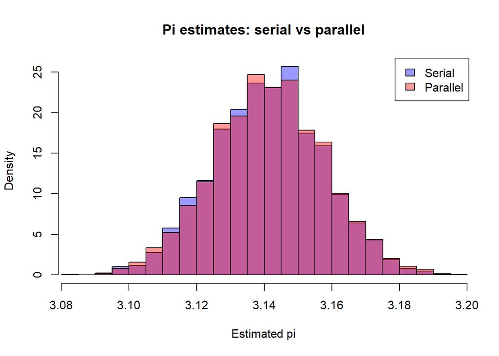

```r
# Visualize that both methods give similar estimates of pi
hist(
  ans_serial,
  breaks = 30,
  freq = FALSE,
  main = "Pi estimates: serial vs parallel",
  xlab = "Estimated pi",
  col = rgb(0, 0, 1, 0.4),
  xlim = range(c(ans_serial, ans_parallel))
)

hist(
  ans_parallel,
  breaks = 30,
  freq = FALSE,
  add = TRUE,
  col = rgb(1, 0, 0, 0.4)
)

legend(
  "topright",
  legend = c("Serial", "Parallel"),
  fill = c(rgb(0, 0, 1, 0.4), rgb(1, 0, 0, 0.4))
)
```

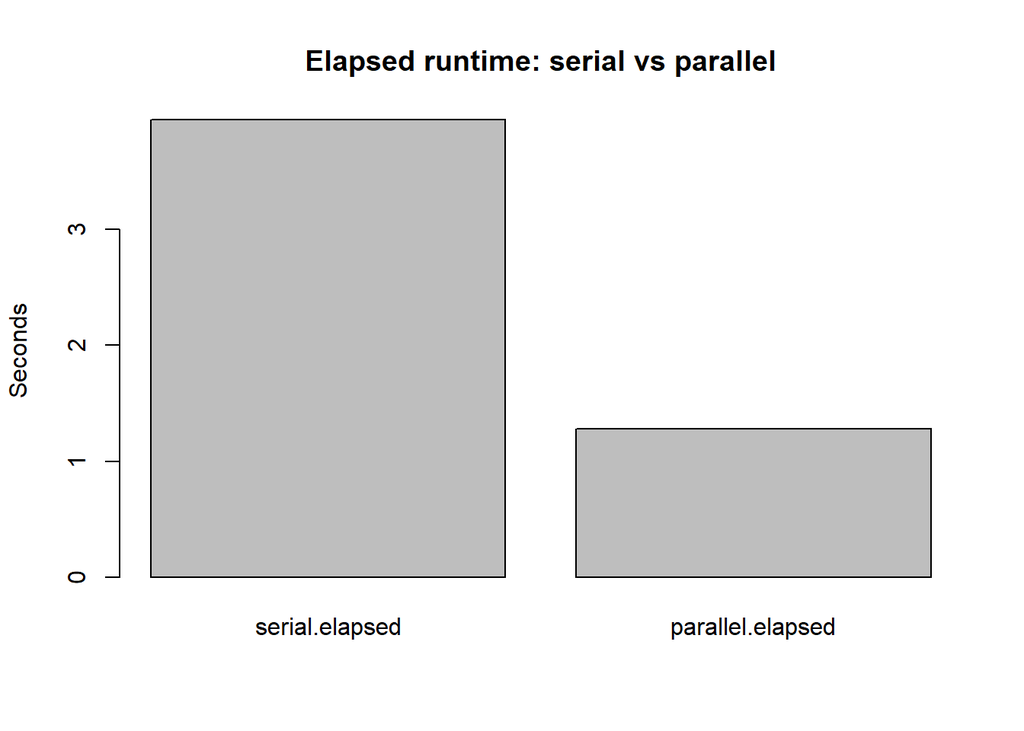

```r
# Barplot comparison
runtime_df <- c(
  serial = serial_time["elapsed"],
  parallel = parallel_time["elapsed"]
)

barplot(
  runtime_df,
  main = "Elapsed runtime: serial vs parallel",
  ylab = "Seconds"
)
```

The parallel version is faster because it distributes the 4000 independent simulation runs across multiple CPU cores so they can be computed simultaneously instead of sequentially.

# SQL

```r
# install.packages(c("RSQLite", "DBI", "readr"))

library(RSQLite)
library(DBI)
library(readr)

# Initialize a temporary in memory database
con <- dbConnect(SQLite(), ":memory:")

# Read in tables
surveys <- read_csv("surveys.csv")
species <- read_csv("species.csv")
plots <- read_csv("plots.csv")
# Copy data.frames to database
dbWriteTable(con, "surveys", surveys, overwrite = TRUE)
dbWriteTable(con, "species", species, overwrite = TRUE)
dbWriteTable(con, "plots", plots, overwrite = TRUE)
```

```r
dbListTables(con)
```

```
[1] "plots"   "species" "surveys"
```

## Question 4: Surveys Summary

```r
dbGetQuery(con,
  "PRAGMA table_info(surveys)"
)
```

```
  cid            name type notnull dflt_value pk
1   0       record_id REAL       0         NA  0
2   1           month REAL       0         NA  0
3   2             day REAL       0         NA  0
4   3            year REAL       0         NA  0
5   4         plot_id REAL       0         NA  0
6   5      species_id TEXT       0         NA  0
7   6             sex TEXT       0         NA  0
8   7 hindfoot_length REAL       0         NA  0
9   8          weight REAL       0         NA  0
```

```r
dbGetQuery(con,
  "SELECT
    year,
    month,
    day,
    species_id,
    ROUND(weight / 1000.0, 2) AS weight_kg
  FROM surveys
  WHERE year = 1999
  ORDER BY species_id"
)
```

```
   year month day species_id weight_kg
1  1999     1  17       <NA>        NA
2  1999     2  21       <NA>        NA
3  1999     2  21       <NA>        NA
4  1999     2  21       <NA>        NA
5  1999     3  15       <NA>        NA
6  1999     3  15       <NA>        NA
7  1999     3  15       <NA>        NA
8  1999     4  17       <NA>        NA
9  1999     4  18       <NA>        NA
10 1999     4  18       <NA>        NA
11 1999     5  16       <NA>        NA
12 1999     6  13       <NA>        NA
13 1999     9  11       <NA>        NA
14 1999     9  11       <NA>        NA
15 1999     9  11       <NA>        NA
16 1999     9  12       <NA>        NA
17 1999     9  12       <NA>        NA
18 1999     9  12       <NA>        NA
19 1999    10   9       <NA>        NA
20 1999    10  10       <NA>        NA
 [ reached 'max' / getOption("max.print") -- omitted 1115 rows ]
```

## Question 5: Animal Weights

```r
# Weights for all animals in 'surveys'
dbGetQuery(con,
  "SELECT
    year,
    month,
    day,
    species_id,
    ROUND(weight / 1000.0, 2) AS weight_kg
  FROM surveys
  WHERE year = 1999
  ORDER BY species_id"
)
```

```
   year month day species_id weight_kg
1  1999     1  17       <NA>        NA
2  1999     2  21       <NA>        NA
3  1999     2  21       <NA>        NA
4  1999     2  21       <NA>        NA
5  1999     3  15       <NA>        NA
6  1999     3  15       <NA>        NA
7  1999     3  15       <NA>        NA
8  1999     4  17       <NA>        NA
9  1999     4  18       <NA>        NA
10 1999     4  18       <NA>        NA
11 1999     5  16       <NA>        NA
12 1999     6  13       <NA>        NA
13 1999     9  11       <NA>        NA
14 1999     9  11       <NA>        NA
15 1999     9  11       <NA>        NA
16 1999     9  12       <NA>        NA
17 1999     9  12       <NA>        NA
18 1999     9  12       <NA>        NA
19 1999    10   9       <NA>        NA
20 1999    10  10       <NA>        NA
 [ reached 'max' / getOption("max.print") -- omitted 1115 rows ]
```

## Question 6: Counts and Weights

```r
species_year_summary <- dbGetQuery(con, "
  SELECT
    year,
    species_id,
    COUNT(*) AS n_counted,
    AVG(weight) AS avg_weight
  FROM surveys
  GROUP BY year, species_id
  ORDER BY year, species_id
")

species_year_summary
```

```
   year species_id n_counted avg_weight
1  1977       <NA>        16         NA
2  1977         DM       264  41.141304
3  1977         DO        12  42.666667
4  1977         DS        98 121.437500
5  1977         NL        31         NA
6  1977         OL        10  21.666667
7  1977         OT        17  21.000000
8  1977         OX         7  21.333333
9  1977         PE         6  19.500000
10 1977         PF        31   7.173913
11 1977         PP         7  15.333333
12 1977         RM         2  10.000000
13 1977         SH         1         NA
14 1977         SS         1         NA
15 1978       <NA>        56         NA
16 1978         AH         1         NA
17 1978         DM       389  40.795455
18 1978         DO        22  45.000000
19 1978         DS       320 115.198653
20 1978         NL        48 184.656250
21 1978         OL        47  31.027027
22 1978         OT        66  23.220000
23 1978         OX         1         NA
24 1978         PE        17  20.428571
25 1978         PF        40   7.088235
 [ reached 'max' / getOption("max.print") -- omitted 510 rows ]
```

## Question 7: Number of Species per Taxa

```r
taxa_counts <- dbGetQuery(con, "
  SELECT
    taxa,
    COUNT(*) AS n_species
  FROM species
  GROUP BY taxa
  HAVING COUNT(*) > 10
  ORDER BY n_species DESC
")

taxa_counts
```

```
    taxa n_species
1 Rodent        31
2   Bird        13
```

## Question 8: Number of Animals per Genus

```r
genus_plot_counts <- dbGetQuery(con, "
  SELECT
    s.plot_id,
    sp.genus,
    COUNT(*) AS n_caught
  FROM surveys AS s
  INNER JOIN species AS sp
    ON s.species_id = sp.species_id
  GROUP BY s.plot_id, sp.genus
  ORDER BY s.plot_id ASC, n_caught DESC
")

genus_plot_counts
```

```
   plot_id            genus n_caught
1        1        Dipodomys     1330
2        1      Chaetodipus      332
3        1        Onychomys      153
4        1          Neotoma       54
5        1      Perognathus       34
6        1       Peromyscus       28
7        1  Reithrodontomys       24
8        1     Spermophilus       12
9        1       Amphispiza        7
10       1 Ammospermophilus        7
11       1           Pipilo        4
12       1       Sylvilagus        2
13       1           Rodent        1
14       1          Baiomys        1
```

[output cut: 20 more lines]

## Question 9: Number of Specimens per Plot

```r
species_plottype_counts <- dbGetQuery(con, "
  SELECT
    p.plot_type,
    s.species_id,
    sp.genus,
    sp.species,
    COUNT(*) AS n_captured
  FROM surveys AS s
  INNER JOIN species AS sp
    ON s.species_id = sp.species_id
  INNER JOIN plots AS p
    ON s.plot_id = p.plot_id
  WHERE s.species_id IS NOT NULL
    AND LOWER(sp.species) <> 'unknown'
  GROUP BY p.plot_type, s.species_id, sp.genus, sp.species
  ORDER BY p.plot_type, n_captured DESC, s.species_id
")

species_plottype_counts
```

```
   plot_type species_id            genus         species n_captured
1    Control         DM        Dipodomys        merriami       6760
2    Control         DO        Dipodomys           ordii       1671
3    Control         DS        Dipodomys     spectabilis       1389
4    Control         PP      Chaetodipus    penicillatus       1108
5    Control         OT        Onychomys        torridus       1004
6    Control         PB      Chaetodipus         baileyi        789
7    Control         NL          Neotoma        albigula        610
8    Control         OL        Onychomys     leucogaster        471
9    Control         PF      Perognathus          flavus        424
10   Control         RM  Reithrodontomys       megalotis        403
11   Control         PE       Peromyscus        eremicus        343
12   Control         AH Ammospermophilus         harrisi        125
13   Control         PM       Peromyscus     maniculatus        120
14   Control         SS     Spermophilus       spilosoma        103
15   Control         AB       Amphispiza       bilineata         76
16   Control         SH         Sigmodon        hispidus         50
17   Control         SA       Sylvilagus       audubonii         29
18   Control         DX        Dipodomys             sp.         27
19   Control         SF         Sigmodon     fulviventer         19
20   Control         CB  Campylorhynchus brunneicapillus         13
 [ reached 'max' / getOption("max.print") -- omitted 161 rows ]
```

## Question 10: Average Weight of Rodent Species

```r
rodent_avg_weight <- dbGetQuery(con, "
  SELECT
    s.species_id,
    sp.genus,
    sp.species,
    AVG(s.weight) AS avg_weight
  FROM surveys AS s
  INNER JOIN species AS sp
    ON s.species_id = sp.species_id
  WHERE sp.taxa = 'Rodent'
  GROUP BY s.species_id, sp.genus, sp.species
  ORDER BY avg_weight DESC
")

rodent_avg_weight
```

```
   species_id           genus      species avg_weight
1          NL         Neotoma     albigula 159.245660
2          DS       Dipodomys  spectabilis 120.130546
3          SS    Spermophilus    spilosoma  93.500000
4          SH        Sigmodon     hispidus  73.148936
5          SF        Sigmodon  fulviventer  58.878049
6          SO        Sigmodon ochrognathus  55.414634
7          DO       Dipodomys        ordii  48.870523
8          DM       Dipodomys     merriami  43.157864
9          PB     Chaetodipus      baileyi  31.735943
10         OL       Onychomys  leucogaster  31.575258
11         PH     Perognathus     hispidus  31.064516
12         OT       Onychomys     torridus  24.230556
13         PE      Peromyscus     eremicus  21.586508
14         PM      Peromyscus  maniculatus  21.364155
15         OX       Onychomys          sp.  21.000000
16         PI     Chaetodipus  intermedius  19.250000
17         PL      Peromyscus     leucopus  19.138889
18         PX     Chaetodipus          sp.  19.000000
19         PP     Chaetodipus penicillatus  17.173942
20         RX Reithrodontomys          sp.  15.500000
21         RF Reithrodontomys   fulvescens  13.386667
22         RM Reithrodontomys    megalotis  10.585010
23         RO Reithrodontomys     montanus  10.250000
24         BA         Baiomys      taylori   8.600000
25         PF     Perognathus       flavus   7.923127
 [ reached 'max' / getOption("max.print") -- omitted 4 rows ]
```

## Question 11: Number of Animals per Genus (ggplotly)

```r
library(dplyr)
library(ggplot2)
library(plotly)
genus_plot_counts_1_5 <- genus_plot_counts %>%
  filter(plot_id %in% 1:5)

p <- ggplot(genus_plot_counts_1_5, aes(x = factor(plot_id), y = n_caught, fill = genus)) +
  geom_col(position = "dodge") +
  labs(
    title = "Number of animals caught by genus for plots 1-5",
    x = "Plot ID",
    y = "Number caught",
    fill = "Genus"
  )

plotly::ggplotly(p)
```

[interactive chart not shown]

## Question 12: Counts and Weights (plotly)

```r
library(dplyr)
library(plotly)

species_year_plot <- species_year_summary %>%
  filter(!is.na(avg_weight))

plot_ly(
  data = species_year_plot,
  x = ~year,
  y = ~avg_weight,
  color = ~species_id,
  type = "scatter",
  mode = "lines+markers",
  hovertemplate = paste(
    "Year: %{x}",
    "<br>Species: %{color}",
    "<br>Average weight: %{y:.2f}",
    "<extra></extra>"
  )
) %>%
  layout(
    title = "Average species weight over time",
    xaxis = list(title = "Year"),
    yaxis = list(title = "Average weight")
  )
```

[interactive chart not shown]

One potential solution to remove noise in this plot is to keep only species that appear in at least 10 years:

```r
species_year_plot_clean <- species_year_summary %>%
  filter(!is.na(avg_weight)) %>%
  group_by(species_id) %>%
  filter(n() >= 10) %>%
  ungroup()

plot_ly(
  data = species_year_plot_clean,
  x = ~year,
  y = ~avg_weight,
  color = ~species_id,
  type = "scatter",
  mode = "lines+markers",
  hovertemplate = paste(
    "Year: %{x}",
    "<br>Species: %{color}",
    "<br>Average weight: %{y:.2f}",
    "<extra></extra>"
  )
) %>%
  layout(
    title = "Average species weight over time (species with at least 10 years of data)",
    xaxis = list(title = "Year"),
    yaxis = list(title = "Average weight")
  )
```

[interactive chart not shown]

We can also remove the markers and keep only the lines in the plot:

```r
plot_ly(
  data = species_year_plot_clean,
  x = ~year,
  y = ~avg_weight,
  color = ~species_id,
  type = "scatter",
  mode = "lines",
  hovertemplate = paste(
    "Year: %{x}",
    "<br>Species: %{color}",
    "<br>Average weight: %{y:.2f}",
    "<extra></extra>"
  )
) %>%
  layout(
    title = "Average species weight over time",
    xaxis = list(title = "Year"),
    yaxis = list(title = "Average weight")
  )
```

[interactive chart not shown]